# Core microbiota of Zamia species

### Zamia Coralloid root Core Cyanobacteria

### Contributors

Juan Carlos Villarreal A.

Adriel M. Sierra

We use the two dataset generated with two amplicon markers to identify the core microbiota.

First we use a subset dataset with only ASVs whose phylum corresponds to Cyanobacteria in the 16S dataset.

```r
knitr::opts_knit$set(root.dir = "/Users/adrielsierra/Documents/GitHub/cycads_rbcLX_roots")
root16ps = readRDS("./Data/Zamia_root_bacteria16s_ps_mai23.rds")
ps_cyano = subset_taxa(root16ps, Phylum=="Cyanobacteria")
```

Second, we use the cyanobacterial community identified with the amplicon marker rbcL-X.

```r
knitr::opts_knit$set(root.dir = "/Users/adrielsierra/Documents/GitHub/cycads_rbcLX_roots")
rbclx.ps = readRDS("./Data/RBCLX_ps_rootZamia.rds")
rbclx.ps
```

```
## phyloseq-class experiment-level object
## otu_table()   OTU Table:         [ 175 taxa and 25 samples ]
## sample_data() Sample Data:       [ 25 samples by 3 sample variables ]
## tax_table()   Taxonomy Table:    [ 175 taxa by 6 taxonomic ranks ]
```

**16S**

*Zamia pseudoparasitica*

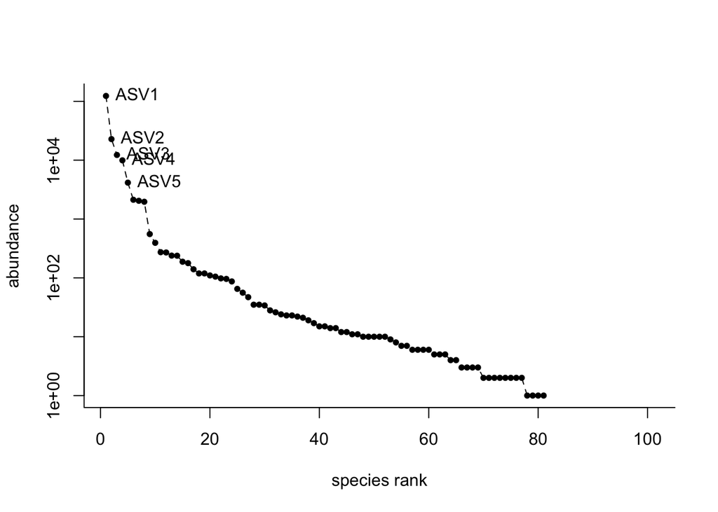

```r
cyano.zpseudo = subset_samples(ps_cyano, Species %in% c("Zamia pseudoparasitica"))
rank.pseudo16 = rankabundance(otu_table(cyano.zpseudo))
rankabunplot(rank.pseudo16, labels=" ",scale="logabun",  lty=2, pch= 20)
```

*Zamia nana*

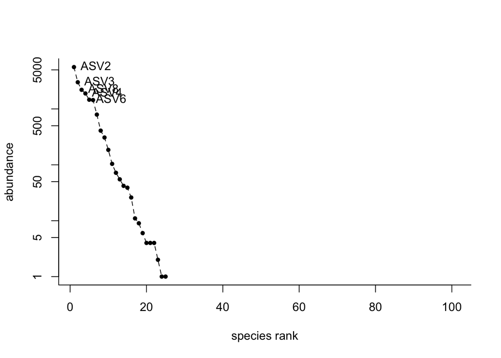

```r
cyano.znana = subset_samples(ps_cyano, Species %in% c("Zamia nana"))
rank.nana16 = rankabundance(otu_table(cyano.znana))
rankabunplot(rank.nana16, labels=" ",scale="logabun",  lty=2, pch= 20)
```

**rbcL-X**

*Zamia pseudoparasitica*

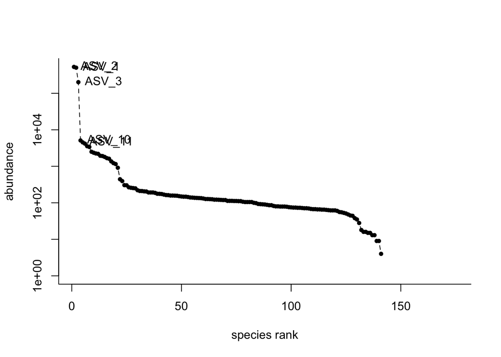

```r
ps_pseudo = subset_samples(rbclx.ps, Species_name %in% c("Zamia pseudoparasitica"))
rank.pseudo = rankabundance(t(otu_table(ps_pseudo)))
rankabunplot(rank.pseudo, labels=" ",scale="logabun",  lty=2, pch= 20)
```

*Zamia nana*

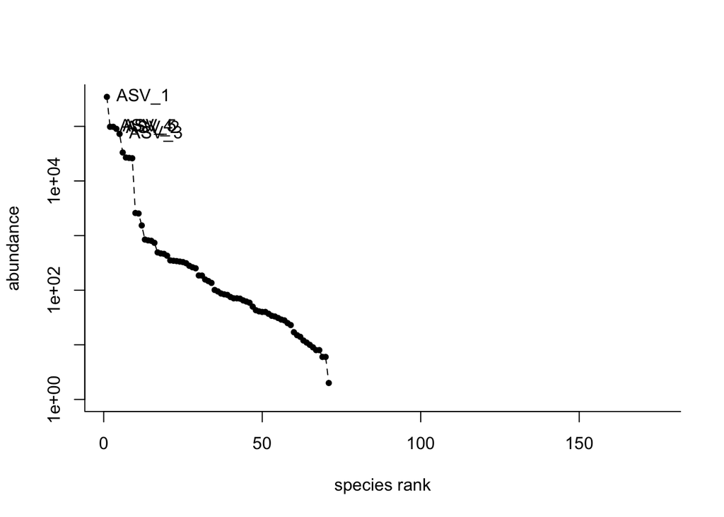

```r
ps_nana = subset_samples(rbclx.ps, Species_name %in% c("Zamia nana"))
rank.nana = rankabundance(t(otu_table(ps_nana)))
rankabunplot(rank.nana, labels=" ",scale="logabun",  lty=2, pch= 20)
```

### Core microbiome.

Indicator species analysis, the labdsv package (version 2.0-1) was used to identify which ASVs were relatively more abundant and predominantly found to one of the specific Zamia species, in contrast to the other host species.

##### The script is adapted from https://bocasbiome.github.io/wf1.html

The Indicator species analysis was done for both marker. A core microbiota was only observed when we analyzed the dataset generated from the rbcL-X marker. Therefore, here is only presented for the rbcL-X.

```r
zamia.host = data.frame(t(otu_table(rbclx.ps)))
cyano.ASV = tibble::remove_rownames(zamia.host)
host.group = data.frame(sample_data(rbclx.ps)) %>%
  select(Species_name)

host.group$Status = host.group$Species
host.group = host.group[, c(2,1)]
host.group$Status = str_replace(host.group$Status, "Zamia nana", "1")
host.group$Status = str_replace(host.group$Status, "Zamia pseudoparasitica", "2")
host.group = tibble::rownames_to_column(host.group, "Label")
host.group$Status =  as.integer(host.group$Status)
host.group$Species =  as.character(host.group$Species)
```

Here we calculate the indicator values.

```r
set.seed(1280)
iva = indval(cyano.ASV, host.group$Status)

gr = iva$maxcls[iva$pval <= 0.01]
iv = iva$indcls[iva$pval <= 0.01]
pv = iva$pval[iva$pval <= 0.01]
fr = apply(cyano.ASV > 0, 2, sum)[iva$pval <= 0.01]
indval.out = data.frame(group = gr, indval = iv, pval = pv, freq = fr)
indval.out = indval.out[order(indval.out$group, -indval.out$indval),]
indval.out
```

```
##       group  indval  pval freq
## ASV_2     2 0.74343 0.004   21
```

```r
indval.out$prob.corrected = p.adjust(indval.out$pval, "bonferroni")

indval.out
```

```
##       group  indval  pval freq prob.corrected
## ASV_2     2 0.74343 0.004   21          0.004
```

### core microbiome using threshold frequency

To allow for comparisons of the core microbiomes, we considered samples that we have amplicon sequencing data for the two markers and from the same locality.

```r
ps_cyano_sub = subset_samples(ps_cyano, Locality !="El Cope")
ps_cyano_prun = prune_taxa(taxa_sums(ps_cyano_sub)!=0, ps_cyano_sub)
```

```r
which(!rowSums(otu_table(rbclx.ps)) > 50)
```

```
## ASV_145 ASV_146 ASV_147 ASV_148 ASV_149 ASV_150 ASV_151 ASV_152 ASV_153 ASV_154
##     145     146     147     148     149     150     151     152     153     154
## ASV_155 ASV_156 ASV_157 ASV_158 ASV_159 ASV_160 ASV_161 ASV_162 ASV_163 ASV_164
##     155     156     157     158     159     160     161     162     163     164
## ASV_166 ASV_167 ASV_168 ASV_170 ASV_171 ASV_172 ASV_173 ASV_176 ASV_177 ASV_180
##     165     166     167     168     169     170     171     172     173     174
## ASV_183
##     175
```

```r
total = median(sample_sums(rbclx.ps))
standf = function(x, t=total) round(t * (x / sum(x)))
rbclx.ps = transform_sample_counts(rbclx.ps, standf)

ps2prun.ra = microbiome::transform(rbclx.ps, "compositional")

ps2prun.ra2 = prune_taxa(taxa_sums(ps2prun.ra) > 0, ps2prun.ra)
taxonomy = as.data.frame(tax_table(ps2prun.ra2))
```

We first extract the taxonomy table. Subset this taxonomy table to include only core ASVs with the different threshold. Total core abundance in each sample (sum of abundances of the core members).

```r
core50_name = core_members(ps2prun.ra2, detection = 0.0001, prevalence = 50/100, include.lowest = FALSE)

core50_seq = core_members(ps2prun.ra2, detection = 0.0001, prevalence = 50/100, include.lowest = FALSE)

core.abundance.50 = sample_sums(core(ps2prun.ra2, detection = 0.0001, prevalence = 50/100))
DT::datatable(as.data.frame(core.abundance.50))
```

|  | core.abundance.50 |
| --- | --- |
| Zn-1R | 1 |
| Zn-25R | 0.644400537603529 |
| Zn-26R | 0.944619307999816 |
| Zn-27R | 0.98595092588338 |
| Zn-28R | 0.0413316178835638 |
| Zn-3R | 0.998460672479351 |
| Zn-4R | 0.999471586275028 |
| Zn-5R | 0.996151725405505 |
| Zn-6R | 0.0541400542204659 |
| Zn-7R | 0.355048074161718 |

[output cut: 15 more lines]

```r
core_taxa_id50 = subset(taxonomy, rownames(taxonomy) %in% core50_name)
DT::datatable(core_taxa_id50)
```

|  | Kingdom | Phylum | Class | Order | Family | Genus |
| --- | --- | --- | --- | --- | --- | --- |
| ASV_1 | Bacteria | Cyanobacteria | Cyanobacteria | Nostocales | Nostocaceae | ASV_1 |
| ASV_2 | Bacteria | Cyanobacteria | Cyanobacteria | Nostocales | Nostocaceae | ASV_2 _KX92289_P430 |
| ASV_3 | Bacteria | Cyanobacteria | Cyanobacteria | Nostocales | Nostocaceae | ASV_3 |
| ASV_6 | Bacteria | Cyanobacteria | Cyanobacteria | Nostocales | Nostocaceae | ASV_6 |
| ASV_7 | Bacteria | Cyanobacteria | Cyanobacteria | Nostocales | Nostocaceae | ASV_7 _MN86557 |
| ASV_10 | Bacteria | Cyanobacteria | Cyanobacteria | Nostocales | Nostocaceae | ASV_10 |
| ASV_11 | Bacteria | Cyanobacteria | Cyanobacteria | Nostocales | Nostocaceae | ASV_11 |
| ASV_12 | Bacteria | Cyanobacteria | Cyanobacteria | Nostocales | Nostocaceae | ASV_12 |
| ASV_14 | Bacteria | Cyanobacteria | Cyanobacteria | Nostocales | Nostocaceae | ASV_14 |
| ASV_15 | Bacteria | Cyanobacteria | Cyanobacteria | Nostocales | Nostocaceae | ASV_15 |

[output cut: 2 more lines]

```r
core75_name = core_members(ps2prun.ra2, detection = 0.0001, prevalence = 75/100, include.lowest = FALSE)

core75_seq = core_members(ps2prun.ra2, detection = 0.0001, prevalence = 75/100, include.lowest = FALSE)

core.abundance.75 = sample_sums(core(ps2prun.ra2, detection = 0.0001, prevalence = 75/100))
DT::datatable(as.data.frame(core.abundance.75))
```

|  | core.abundance.75 |
| --- | --- |
| Zn-1R | 0.634953820704866 |
| Zn-25R | 0.636290535650695 |
| Zn-26R | 0.892340210448927 |
| Zn-27R | 0.968559022193631 |
| Zn-28R | 0.0404815512567201 |
| Zn-3R | 0.998460672479351 |
| Zn-4R | 0.999471586275028 |
| Zn-5R | 0.996151725405505 |
| Zn-6R | 0 |
| Zn-7R | 6.89235293441926e-05 |

[output cut: 15 more lines]

```r
core_taxa_id75 = subset(taxonomy, rownames(taxonomy) %in% core75_name)
DT::datatable(core_taxa_id75)
```

|  | Kingdom | Phylum | Class | Order | Family | Genus |
| --- | --- | --- | --- | --- | --- | --- |
| ASV_1 | Bacteria | Cyanobacteria | Cyanobacteria | Nostocales | Nostocaceae | ASV_1 |
| ASV_2 | Bacteria | Cyanobacteria | Cyanobacteria | Nostocales | Nostocaceae | ASV_2 _KX92289_P430 |
| ASV_3 | Bacteria | Cyanobacteria | Cyanobacteria | Nostocales | Nostocaceae | ASV_3 |

```r
core90_name = core_members(ps2prun.ra2, detection = 0.0001, prevalence = 90/100, include.lowest = FALSE)

core90_seq = core_members(ps2prun.ra2, detection = 0.0001, prevalence = 90/100, include.lowest = FALSE)

core.abundance.90 = sample_sums(core(ps2prun.ra2, detection = 0.0001, prevalence = 90/100))
DT::datatable(as.data.frame(core.abundance.90))
```

|  | core.abundance.90 |
| --- | --- |
| Zn-1R | 0.07658640812388 |
| Zn-25R | 0.19907412725581 |
| Zn-26R | 0.169565317281625 |
| Zn-27R | 0.41722189036438 |
| Zn-28R | 0.0194251711620641 |
| Zn-3R | 0.998265384659567 |
| Zn-4R | 0.999471586275028 |
| Zn-5R | 0.996151725405505 |
| Zn-6R | 0 |
| Zn-7R | 0 |

[output cut: 15 more lines]

```r
core_taxa_id90 = subset(taxonomy, rownames(taxonomy) %in% core90_name)
DT::datatable(core_taxa_id90)
```

|  | Kingdom | Phylum | Class | Order | Family | Genus |
| --- | --- | --- | --- | --- | --- | --- |
| ASV_1 | Bacteria | Cyanobacteria | Cyanobacteria | Nostocales | Nostocaceae | ASV_1 |

Visualitation of the core microbiome with Core line plots considering the compositional (relative) abundances.

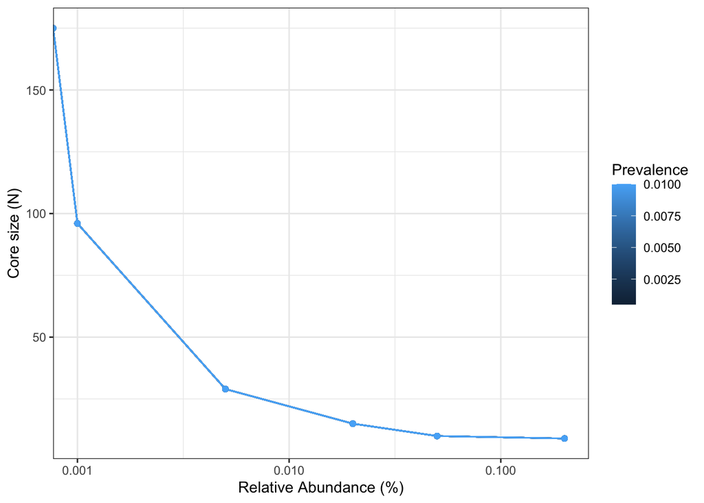

```r
det = c(0, 0.1, 0.5, 2, 5, 20)/100
prevalences = seq(.05, 1, .05)

plot_core(ps2prun.ra2, prevalences = prevalences,
          detections = det, plot.type = "lineplot") +
  xlab("Relative Abundance (%)") +
  theme_bw()
```

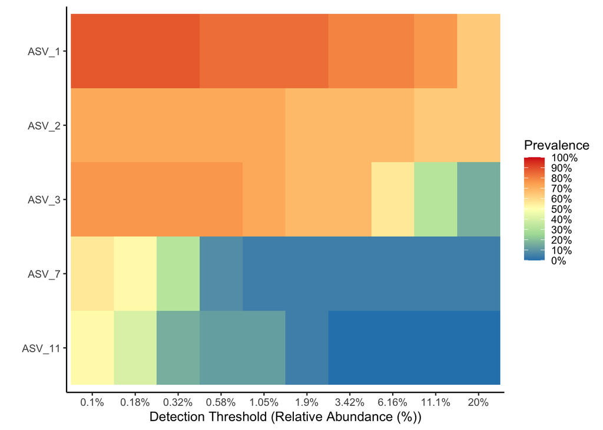

```r
prevalences = seq(.05, 1, .05)
detections = round(10^seq(log10(1e-3), log10(.2), length = 10), digits = 4)

p.core = plot_core(ps2prun.ra2,
                    plot.type = "heatmap",
                    colours = rev(brewer.pal(5, "Spectral")),
                    prevalences = prevalences,
                    detections = detections,
                    min.prevalence = .5) + theme_classic() +
xlab("Detection Threshold (Relative Abundance (%))")

p.core
```